# Visualizing Time Series Data in R

Week 2 R-lab  
Zhaohu(Jonathan) Fan

05/20/2021

# A Data Example

Our goals are to **plot the time series** and **create a seasonal plot for the last four years of the series.**

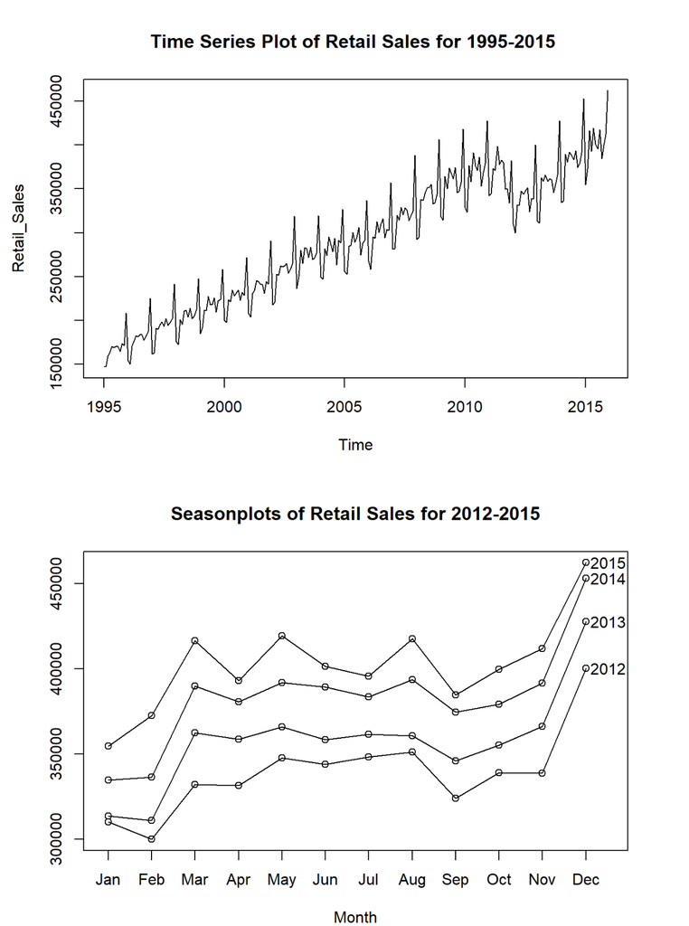

# Step 1: Set working directory

**Set working directory (before Coding)**

```r
setwd("C:/Users/fanzh/OneDrive - University of Cincinnati/UC_couse/000_Teaching_4090_SS21/Labs/Week2/Lab3_data_visulization")
```

Note: I provide R code for most examples in shaded boxes (so-called R chunks, shown in grey) like this:

```r
pi
```

```
## [1] 3.141593
```

# Hints for Step 1

$\color{red}{\text{Always set working directory before you start coding.}}$

- step 1: Click **Session -> Set Working Directory -> Choose Directory**, then choose the folder to which you wish to save your work.

[figure not shown]

# Hints for Step 1 (cont’d) $\color{red}{\text{Very Important!!}}$

- step 2: Copy that working directory from your console into an R code chunk. In other words, you need to type `setwd()` such as setwd(“C:/Users/fanzh/OneDrive - University of Cincinnati/UC_couse/000_Teaching_4090_SS21/Labs/Week2/Lab3_data_visulization”) in the R code chunk.

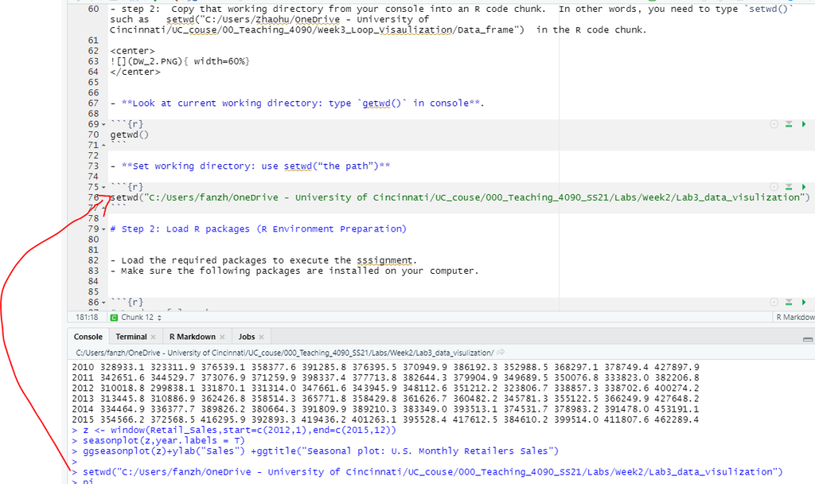

- **Look at current working directory: type `getwd()` in console**.

```r
getwd()
```

- **Set working directory: use setwd(“the path”)**

```r
setwd("C:/Users/fanzh/OneDrive - University of Cincinnati/UC_couse/000_Teaching_4090_SS21/Labs/Week2/Lab3_data_visulization")
```

# Step 2: Load R packages (R Environment Preparation)

- Load the required packages to execute the asssignment.
- Make sure the following packages are installed on your computer.

```r
# Load useful packages
##library(forecast)
library(zoo)
library(readxl)
library(forecast)
library(quantmod)
library(ggplot2)
```

# Hints for Step 2

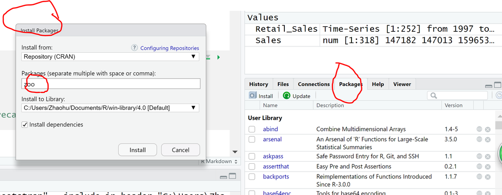

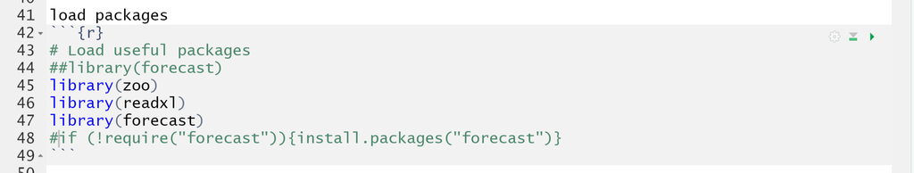

# Step 3 : Read data set

`readxl` is one of the newest packages for accessing Excel data with R. `readxlsx` function can import Excel data with format from the file extension (.xlsx).

```r
library(readxl)
US_Retail_sales<- read_xlsx("RetailSales2018_clean.xlsx")
head(US_Retail_sales)
```

```
## # A tibble: 6 x 5
##    Year Month   Sales S_Factor   CPI
##   <dbl> <chr>   <dbl>    <dbl> <dbl>
## 1  1992 JAN   147182.    0.897  138.
## 2  1992 FEB   147013.    0.895  139.
## 3  1992 MAR   159653.    0.975  139.
## 4  1992 APR   163606.    0.993  140.
## 5  1992 MAY   170089.    1.03   140.
## 6  1992 JUN   168922.    1.02   140.
```

```r
str(US_Retail_sales$Sales)
```

```
##  num [1:318] 147182 147013 159653 163606 170089 ...
```

# Hints for Step 3

- **To read in the CSV file, we can use `read.csv("mydata.csv")`**
- **To load R data/objects, we can use `load("mydata.RData")`**

# Step 4: Store the data in a conveniently named variable

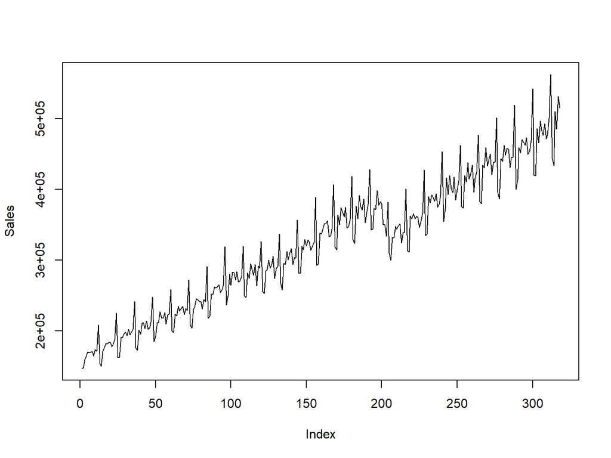

```r
Sales<- US_Retail_sales$Sales
# Figure 1.2
plot(Sales, type = "l")
```

# Hints for Step 4

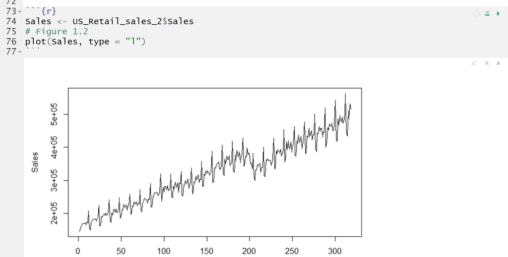

# Step 5 : Change to Time-Series Object

```r
library(forecast)
library(quantmod)
Retail_Sales <- ts(US_Retail_sales$Sales, start = as.yearmon("1995-01"),end = as.yearmon("2015-12"),freq = 12)
head(Retail_Sales)
```

```
##           Jan      Feb      Mar      Apr      May      Jun
## 1995 147182.5 147012.7 159653.3 163605.7 170088.7 168921.7
```

# Hints for Step 5

- The help page of `ts` function can be opened by two methods: `help(ts)` or `?ts`.

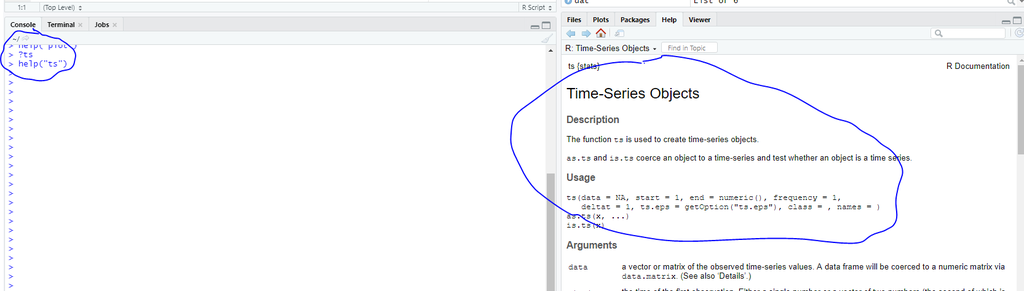

- We can convert this data frame to a time series object by use the ts() function.
- **first argument supplies the `US_Retail_sales_2` data frame and we index for just the columns with the data (we store the date-time data separately).**
- **second argument supplies the start time of the period of interest. (first period in 1995-01)**.
- **thied argument supplies the end time of the period of interest. (last period in 2015-12)**.
- **fourth argument identifies the frequency, which in this case is monthly (hence 12 months in a year)**.

# Step 6: First we plot the complete time series.

- We use the function plot

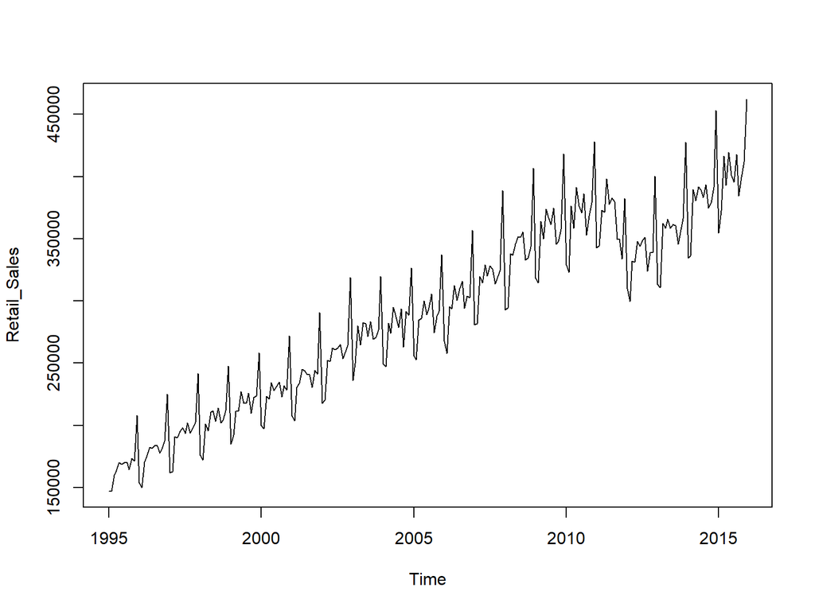

```r
# install.packages("forecast")
plot(Retail_Sales)
```

# Hints for Step 6

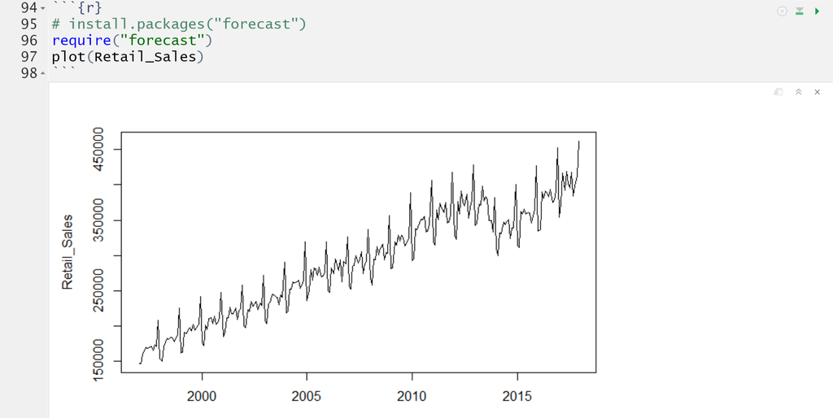

# Step 7: Produce the seasonal plot of the last 4 years.

We use the function seasonplot from the forecast package

```r
library(forecast)
library(quantmod)
library(ggplot2)
US_Retail_sales<- readxl::read_xlsx("RetailSales2018_clean.xlsx")
Retail_Sales <- ts(US_Retail_sales$Sales, start = as.yearmon("1995-01"),end = as.yearmon("2015-12"),freq = 12)
head(Retail_Sales)
```

```
##           Jan      Feb      Mar      Apr      May      Jun
## 1995 147182.5 147012.7 159653.3 163605.7 170088.7 168921.7
```

# Step 7: Produce the seasonal plot of the last 4 years (cont’d).

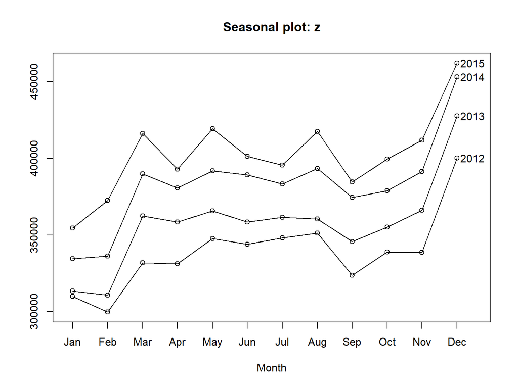

```r
z <- window(Retail_Sales,start=c(2012,1),end=c(2015,12))
seasonplot(z,year.labels = T)
```

# Step 7: Produce the seasonal plot of the last 4 years (cont’d).

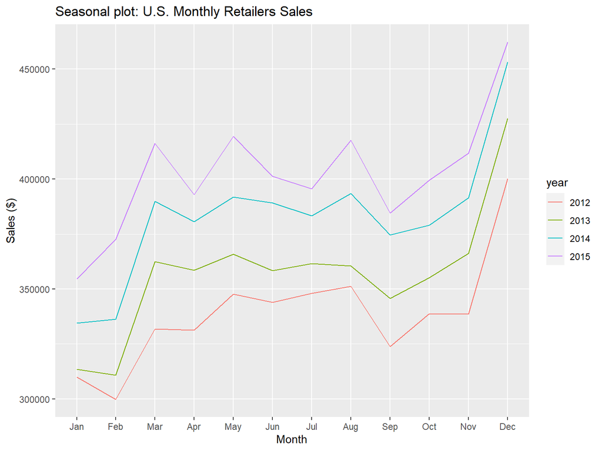

```r
ggseasonplot(z)+ylab("Sales ($)") +ggtitle("Seasonal plot: U.S. Monthly Retailers Sales")
```

# Hints for Step 7

`window` is a generic function which extracts the subset of the object x observed between the times `start` and `end`. If a frequency is specified, the series is then re-sampled at the new frequency.

- The help page of `window` function can be opened by two methods: `help(window)` or `?window`.
- **first argument supplies the `Retail_Sales` a time-series**
- **second argument supplies the start time of the period of interest. (first period in 2012-01)**.
- **third argument supplies the end time of the period of interest. (last period in 2015-12)**.

# **Exercises (1): Let’s practice!**

- Help() !
- There are many functions in R. It is often hard to remember all the argument names and details of the functions. Luckily, every single function has a help page. Using the help pages is part of using R. The help page of a function called func can be opened by two methods: `help(func)` or `?func`.
- Open the help page of plot by writing ?plot directly to the console and press enter.
- Use `plot()` to draw a time series plot of retail sales for 1995-2015, with time on the x axis and retail_sales on the y axis.
- **Use the information on the help page and add this main title to the plot: “Time Series Plot of Retail Sales for 1995-2015”**.
- Use `seasonplot()` to draw seasonplots of retail sales for 2012-2015,with time on the x axis and retail_sales on the y axis.
- **Use the information on the help page and add this main title to the plot: “Seasonplots of Retail Sales for 2012-2015”**.

# **Hints ?**

# No

I’m good!

# Yes

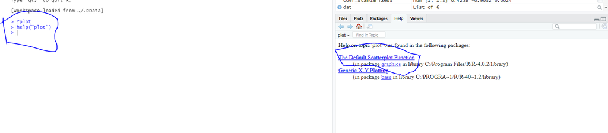

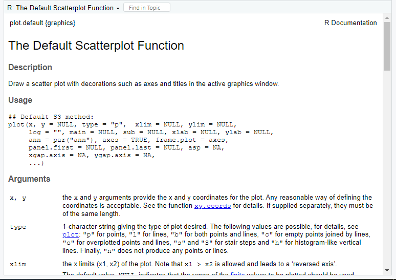

# Needs More?

# **Exercises (2): Let’s practice!**

> The monthly figures for US Retail Sales, from $\color{red}{\text{January 2001 to December 2012}}$ are given in $\color{red}{\text{data_US_Retail_Sales.Rdata}}.$
- Plot the time series with the main title
- Create a seasonal plot for the last four years of the series with the main title.

> Hints:
- To load R data/objects, we can use `load("mydata.RData")`. For example, we can call `load("data_US_Retail_Sales.Rdata")` in Rstudio.
- To read in the CSV file, we can use `read.csv("mydata.csv")`